# Untitled

Marjorie Blanco

1/26/2019

## Problem 1: Short Answers

Suppose you are the bank manager and your service goal is to realize wait times of 60 seconds of less, with wait times in excess of 120 seconds being considered intolerable. Based on Figure 6.1 through 6.6 (Call Center Operations for Monday, Tuesday, Wednesday, Thursday, Friday, and Sunday) in page 69 –71:

For each day, give an approximated percentage of the ribbons fall above the 120 seconds line. What kind of actions would you take? Please be as specific as possible.

Frequency of calls by day of week

| Day of Week | Frequency |
| --- | --- |
| Sunday | 6120 |
| Monday | 5722 |
| Tuesday | 6339 |
| Wednesday | 6289 |
| Thursday | 5785 |
| Friday | 1931 |
| Saturday | 857 |

Frequency of calls in February by hour and day of week

|  | 0 | 1 | 2 | 3 | 4 | 5 | 6 | 7 | 8 | 9 | 10 | 11 | 12 | 13 | 14 | 15 | 16 | 17 | 18 | 19 | 20 | 21 | 22 | 23 |
| --- | --- | --- | --- | --- | --- | --- | --- | --- | --- | --- | --- | --- | --- | --- | --- | --- | --- | --- | --- | --- | --- | --- | --- | --- |
| Sunday | 20 | 7 | 2 | 1 | 0 | 3 | 14 | 147 | 410 | 456 | 494 | 436 | 358 | 384 | 428 | 414 | 581 | 494 | 302 | 244 | 169 | 364 | 259 | 133 |
| Monday | 13 | 8 | 1 | 1 | 0 | 4 | 26 | 174 | 394 | 471 | 463 | 451 | 372 | 401 | 475 | 413 | 333 | 262 | 363 | 258 | 250 | 208 | 190 | 191 |
| Tuesday | 11 | 6 | 4 | 2 | 2 | 6 | 21 | 183 | 384 | 411 | 532 | 490 | 386 | 433 | 464 | 483 | 556 | 429 | 353 | 275 | 271 | 259 | 211 | 167 |
| Wednesday | 27 | 7 | 5 | 0 | 2 | 1 | 19 | 158 | 389 | 430 | 496 | 441 | 382 | 814 | 463 | 462 | 271 | 300 | 355 | 342 | 272 | 246 | 230 | 177 |
| Thursday | 25 | 2 | 2 | 0 | 0 | 5 | 21 | 147 | 327 | 400 | 513 | 440 | 381 | 374 | 471 | 495 | 579 | 402 | 295 | 213 | 212 | 162 | 174 | 145 |
| Friday | 26 | 2 | 7 | 3 | 5 | 3 | 10 | 94 | 304 | 296 | 274 | 297 | 286 | 186 | 80 | 26 | 8 | 4 | 5 | 3 | 8 | 3 | 0 | 1 |
| Saturday | 0 | 2 | 0 | 0 | 0 | 0 | 0 | 0 | 0 | 5 | 1 | 2 | 0 | 0 | 4 | 4 | 5 | 6 | 21 | 237 | 165 | 145 | 124 | 136 |

Frequency of calls in week by hour and day of week for first week of February 1999

|  | 0 | 1 | 2 | 3 | 4 | 5 | 6 | 7 | 8 | 9 | 10 | 11 | 12 | 13 | 14 | 15 | 16 | 17 | 18 | 19 | 20 | 21 | 22 | 23 |
| --- | --- | --- | --- | --- | --- | --- | --- | --- | --- | --- | --- | --- | --- | --- | --- | --- | --- | --- | --- | --- | --- | --- | --- | --- |
| Sunday | 7 | 2 | 1 | 1 | 0 | 2 | 6 | 34 | 124 | 129 | 128 | 130 | 102 | 83 | 109 | 108 | 155 | 103 | 64 | 43 | 50 | 62 | 47 | 42 |
| Monday | 4 | 3 | 1 | 0 | 0 | 1 | 9 | 50 | 134 | 118 | 110 | 127 | 92 | 106 | 109 | 96 | 88 | 68 | 120 | 69 | 87 | 61 | 49 | 45 |
| Tuesday | 2 | 2 | 1 | 0 | 0 | 4 | 9 | 58 | 124 | 131 | 158 | 130 | 114 | 132 | 133 | 147 | 157 | 115 | 81 | 89 | 66 | 75 | 51 | 55 |
| Wednesday | 7 | 2 | 2 | 0 | 1 | 1 | 5 | 41 | 119 | 104 | 125 | 125 | 102 | 494 | 145 | 117 | 64 | 68 | 83 | 104 | 66 | 68 | 49 | 46 |
| Thursday | 6 | 0 | 0 | 0 | 0 | 1 | 2 | 32 | 66 | 95 | 117 | 91 | 83 | 87 | 95 | 105 | 152 | 106 | 81 | 70 | 62 | 34 | 43 | 36 |
| Friday | 3 | 0 | 4 | 1 | 1 | 1 | 2 | 28 | 79 | 68 | 75 | 93 | 77 | 48 | 22 | 7 | 4 | 0 | 0 | 2 | 1 | 0 | 0 | 0 |
| Saturday | 0 | 2 | 0 | 0 | 0 | 0 | 0 | 0 | 0 | 3 | 0 | 2 | 0 | 0 | 1 | 0 | 1 | 0 | 5 | 66 | 37 | 37 | 27 | 28 |

Wait-time ribbon plots for the days that the bank was open during the first week of February 1999.

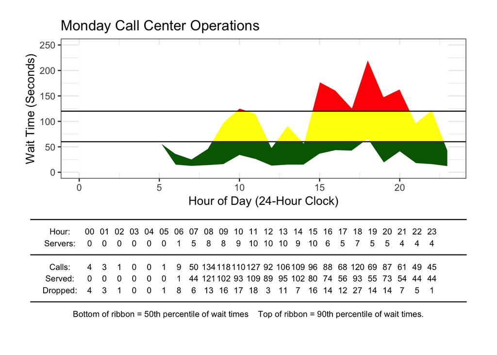

```
## [1] "On Monday the approximate percentage that fall above the 120 seconds line is  10.5 %"
```

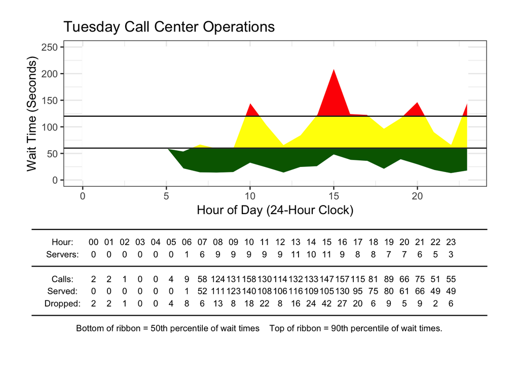

```
## [1] "On Tuesday the approximate percentage that fall above the 120 seconds line is  9 %"
```

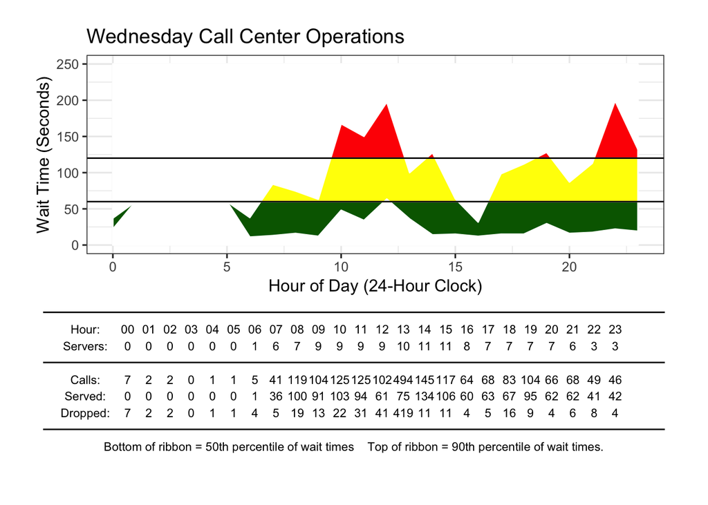

```
## [1] "On Wednesday the approximate percentage that fall above the 120 seconds line is  9.2 %"
```

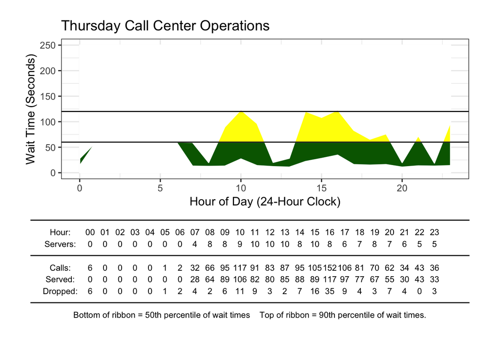

```
## [1] "On Thursday the approximate percentage that fall above the 120 seconds line is  5.3 %"
```

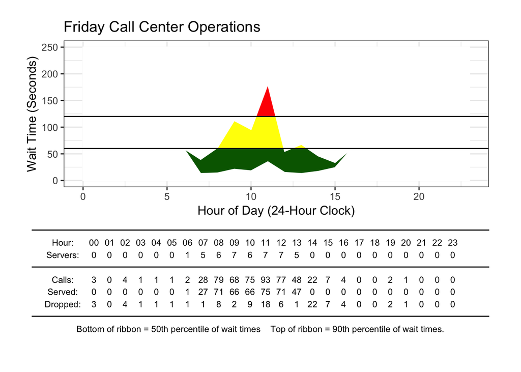

```
## [1] "On Friday the approximate percentage that fall above the 120 seconds line is  5.6 %"
```

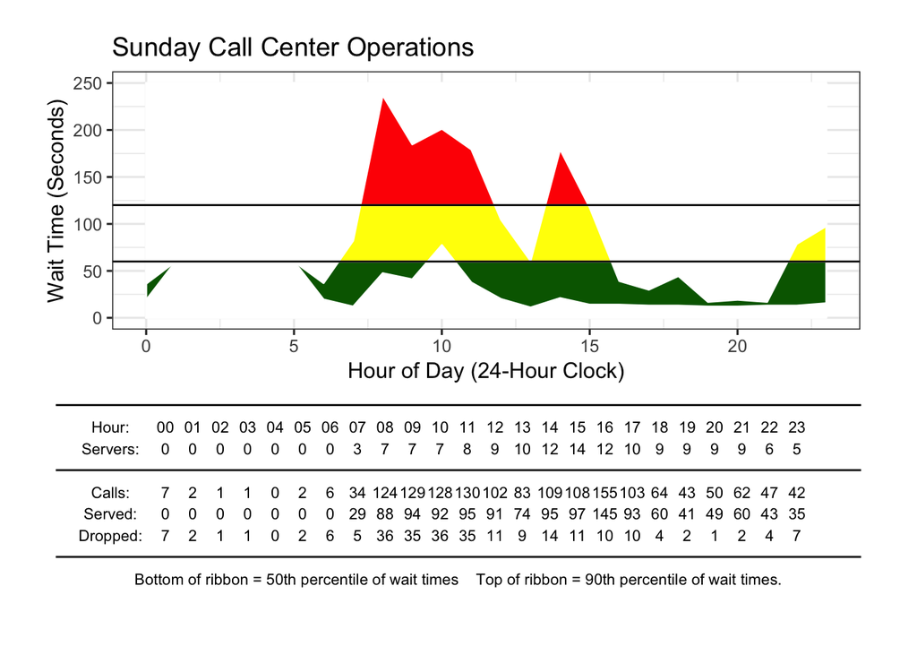

```
## [1] "On Sunday the approximate percentage that fall above the 120 seconds line is  11.4 %"
```

### Recomendations

| Day of Week | Percentage |
| --- | --- |
| Monday | 10.5 |
| Tuesday | 9 |
| Wednesday | 9.2 |
| Thursday | 5.3 |
| Friday | 5.6 |
| Sunday | 11.4 |

Sunday, Monday and Wednesday are the top 3 days where percentage of the ribbons fall above the 120 seconds line. My recomendation is to apply labor planning (LP) problems to address staffing needs over a specific time period (i.e. shift). This models is useful when managers has flexibility in assigning workers to jobs that require overlapping or interchangeable talents. The bank manager would set a schedule that would minimize its total personnel costs. The objective is to minimize cost. There is a constraint for each shift of the day, stating that the number of people working at the bank during that shift should be at least the minimum number shown in the tables bellow, so there are eight of these constraints.

## Problem 2: Short Answers

In page 75 of the textbook (Chapter 6), the author mentioned “optimal solution”. Use your own words to answer the following questions, be sure to explain in details.

What is the optimal solution?

In linear program an optimal solution (i.e. feasible solution) with the largest objective function value (for a maximization problem) or lowest objective function value (for a minimization problem). It is possible for some problems to have more than one optimal solution.

The workforce scheduling is a minimization problem where workers must be scheduled such that resource needs are meet while minimizing costs.

How to find the optimal solutions?

To find optimal solutions, both queing theory and interger programing will be utilized The goal is to minimize total call operator costs while not exceeding constraints, hourly needs.

Assumptions:

- Bbank call center will be closed hours 00 through 05.
- Conversion rate from Israeli shekels to United States dollars was 1 ILS = 3.61 USD in June 2013.

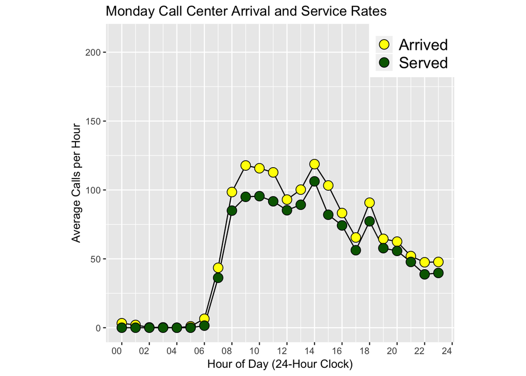

```
##
##  Hourly service rate:[1] 15.58376
##
##  ----- Hourly Operator Requirements -----
##  [1] 0 0 0 0 0 0 1 4 8 9 9 9 8 8 9 8 7 6 8 6 6 5 4 5
##
##  ----- Call Center Shift Constraint Matrix -----
##       Shift1 Shift2 Shift3 Shift4 Shift5 Shift6 Shift7 Shift8 Need
##  [1,]      1      0      0      0      0      0      0      0    0
##  [2,]      1      0      0      0      0      0      0      0    0
##  [3,]      1      0      0      0      0      0      0      0    0
##  [4,]      1      0      0      0      0      0      0      0    0
##  [5,]      1      0      0      0      0      0      0      0    0
##  [6,]      1      0      0      0      0      0      0      0    0
##  [7,]      0      1      0      0      0      0      0      0    1
```

[output cut: 42 more lines]

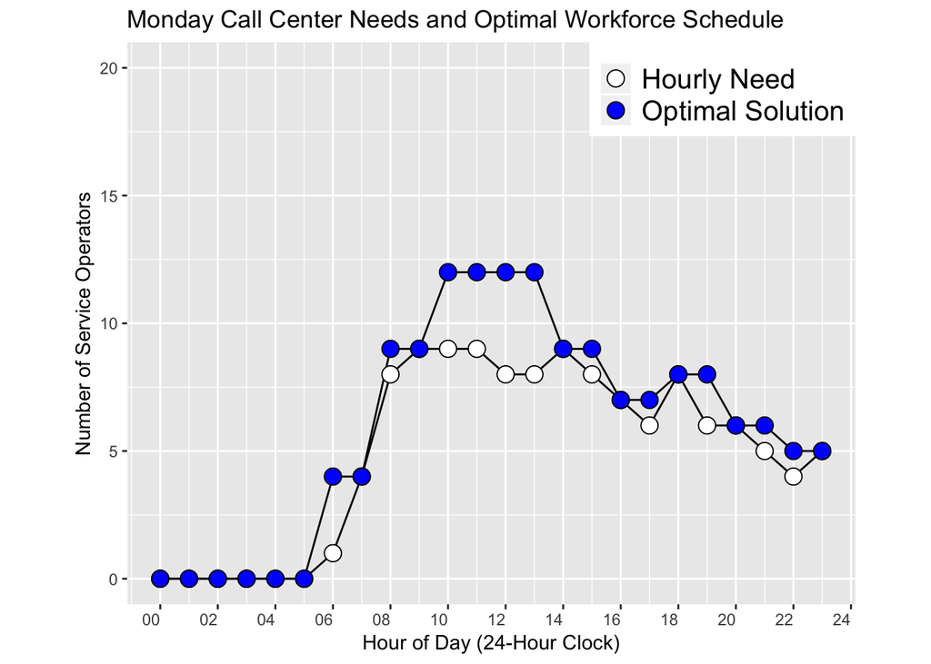

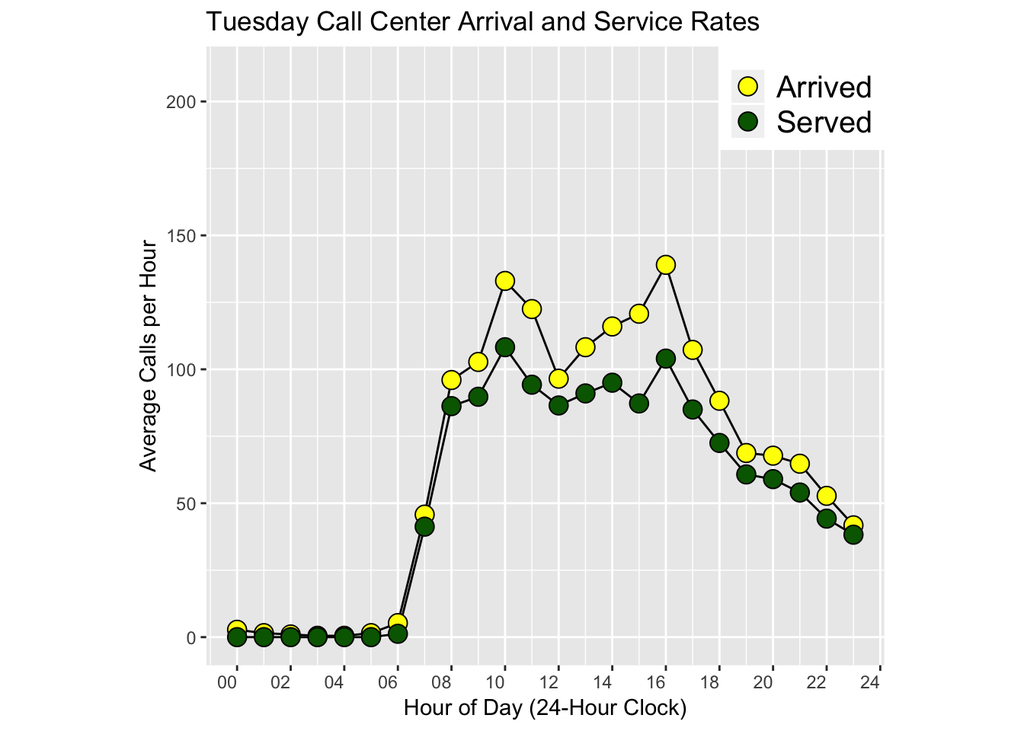

```
##
##  Hourly service rate:[1] 16.00215
##
##  ----- Hourly Operator Requirements -----
##  [1]  0  0  0  0  0  0  1  4  8  8 10 10  8  9  9 10 11  9  7  6  6  6  5
## [24]  4
##
##  ----- Call Center Shift Constraint Matrix -----
##       Shift1 Shift2 Shift3 Shift4 Shift5 Shift6 Shift7 Shift8 Need
##  [1,]      1      0      0      0      0      0      0      0    0
##  [2,]      1      0      0      0      0      0      0      0    0
##  [3,]      1      0      0      0      0      0      0      0    0
##  [4,]      1      0      0      0      0      0      0      0    0
##  [5,]      1      0      0      0      0      0      0      0    0
##  [6,]      1      0      0      0      0      0      0      0    0
```

[output cut: 43 more lines]

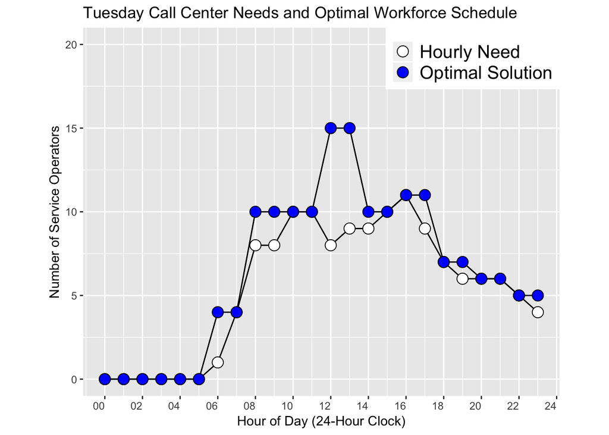

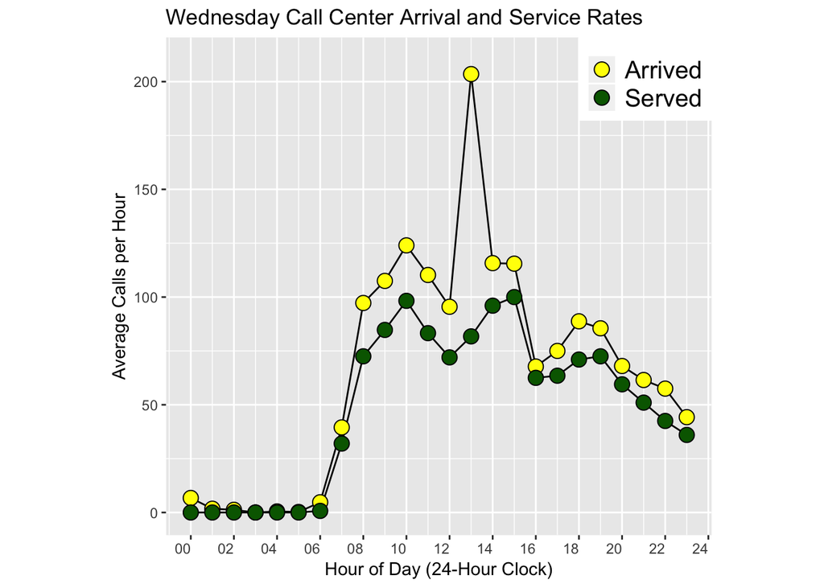

```
##
##  Hourly service rate:[1] 14.86443
##
##  ----- Hourly Operator Requirements -----
##  [1]  0  0  0  0  0  0  1  4  8  9 10  9  8 16 10 10  6  7  8  8  6  6  5
## [24]  4
##
##  ----- Call Center Shift Constraint Matrix -----
##       Shift1 Shift2 Shift3 Shift4 Shift5 Shift6 Shift7 Shift8 Need
##  [1,]      1      0      0      0      0      0      0      0    0
##  [2,]      1      0      0      0      0      0      0      0    0
##  [3,]      1      0      0      0      0      0      0      0    0
##  [4,]      1      0      0      0      0      0      0      0    0
##  [5,]      1      0      0      0      0      0      0      0    0
##  [6,]      1      0      0      0      0      0      0      0    0
```

[output cut: 43 more lines]

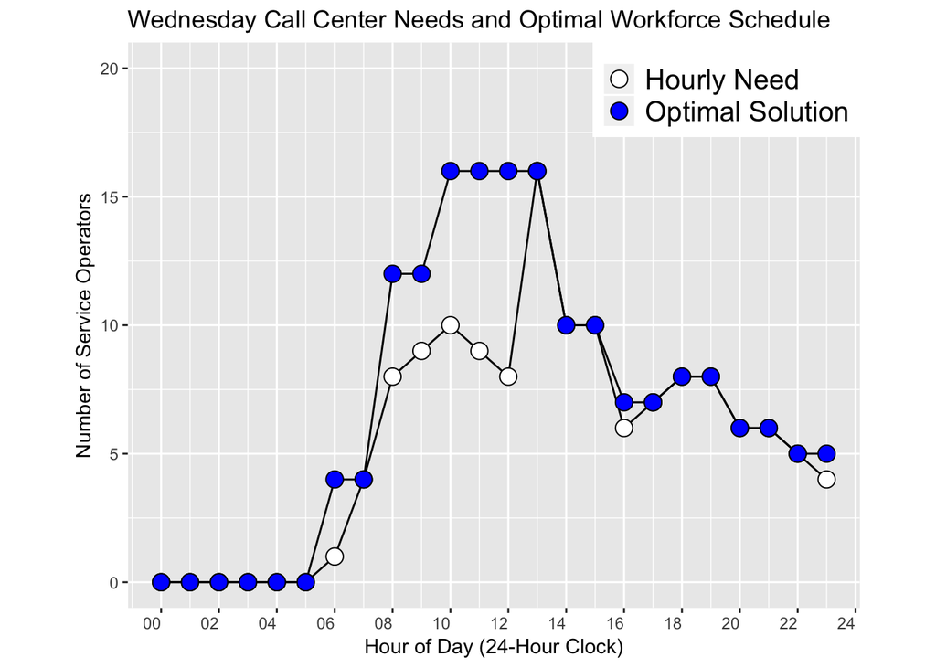

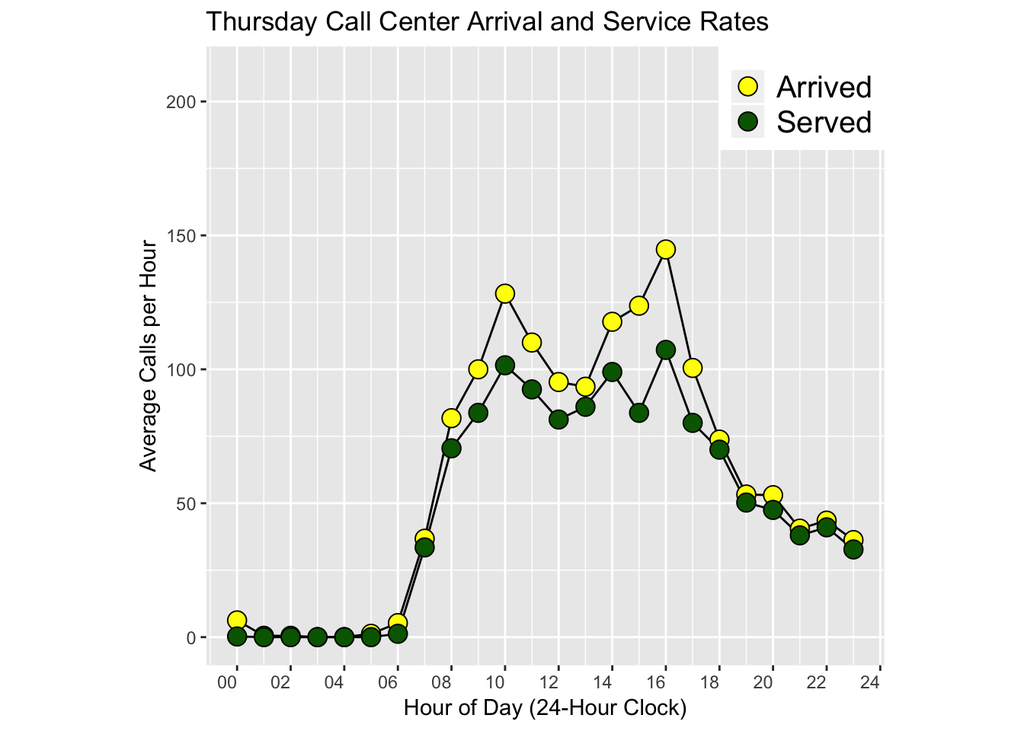

```
##
##  Hourly service rate:[1] 17.3122
##
##  ----- Hourly Operator Requirements -----
##  [1]  0  0  0  0  0  0  1  4  7  8 10  8  7  7  9  9 11  8  6  5  5  4  4
## [24]  4
##
##  ----- Call Center Shift Constraint Matrix -----
##       Shift1 Shift2 Shift3 Shift4 Shift5 Shift6 Shift7 Shift8 Need
##  [1,]      1      0      0      0      0      0      0      0    0
##  [2,]      1      0      0      0      0      0      0      0    0
##  [3,]      1      0      0      0      0      0      0      0    0
##  [4,]      1      0      0      0      0      0      0      0    0
##  [5,]      1      0      0      0      0      0      0      0    0
##  [6,]      1      0      0      0      0      0      0      0    0
```

[output cut: 43 more lines]

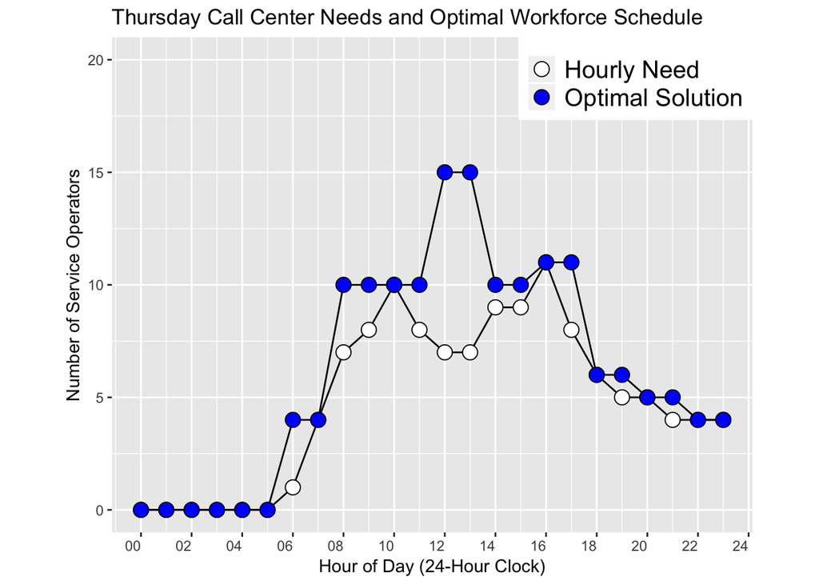

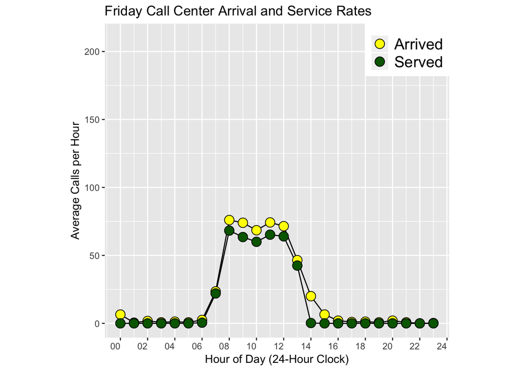

```
##
##  Hourly service rate:[1] 16.45526
##
##  ----- Hourly Operator Requirements -----
##  [1] 0 0 0 0 0 0 1 3 7 6 6 6 6 4 2 1 1 1 1 1 1 1 0 1
##
##  ----- Call Center Shift Constraint Matrix -----
##       Shift1 Shift2 Shift3 Shift4 Shift5 Shift6 Shift7 Shift8 Need
##  [1,]      1      0      0      0      0      0      0      0    0
##  [2,]      1      0      0      0      0      0      0      0    0
##  [3,]      1      0      0      0      0      0      0      0    0
##  [4,]      1      0      0      0      0      0      0      0    0
##  [5,]      1      0      0      0      0      0      0      0    0
##  [6,]      1      0      0      0      0      0      0      0    0
##  [7,]      0      1      0      0      0      0      0      0    1
```

[output cut: 42 more lines]

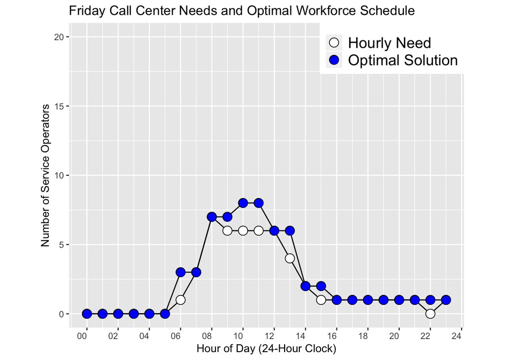

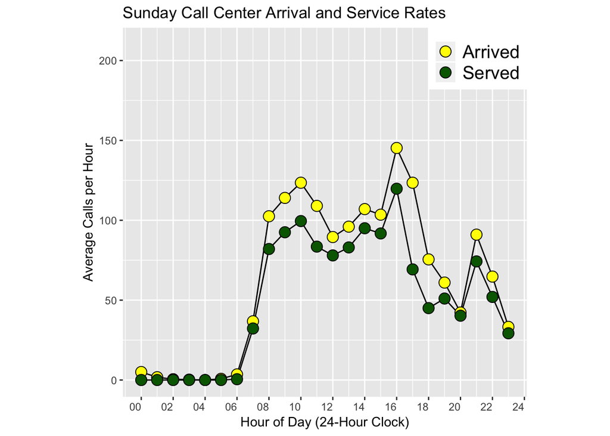

```
##
##  Hourly service rate:[1] 16.26824
##
##  ----- Hourly Operator Requirements -----
##  [1]  0  0  0  0  0  0  1  4  8  9 10  9  7  8  9  8 11 10  6  5  4  8  6
## [24]  3
##
##  ----- Call Center Shift Constraint Matrix -----
##       Shift1 Shift2 Shift3 Shift4 Shift5 Shift6 Shift7 Shift8 Need
##  [1,]      1      0      0      0      0      0      0      0    0
##  [2,]      1      0      0      0      0      0      0      0    0
##  [3,]      1      0      0      0      0      0      0      0    0
##  [4,]      1      0      0      0      0      0      0      0    0
##  [5,]      1      0      0      0      0      0      0      0    0
##  [6,]      1      0      0      0      0      0      0      0    0
```

[output cut: 43 more lines]

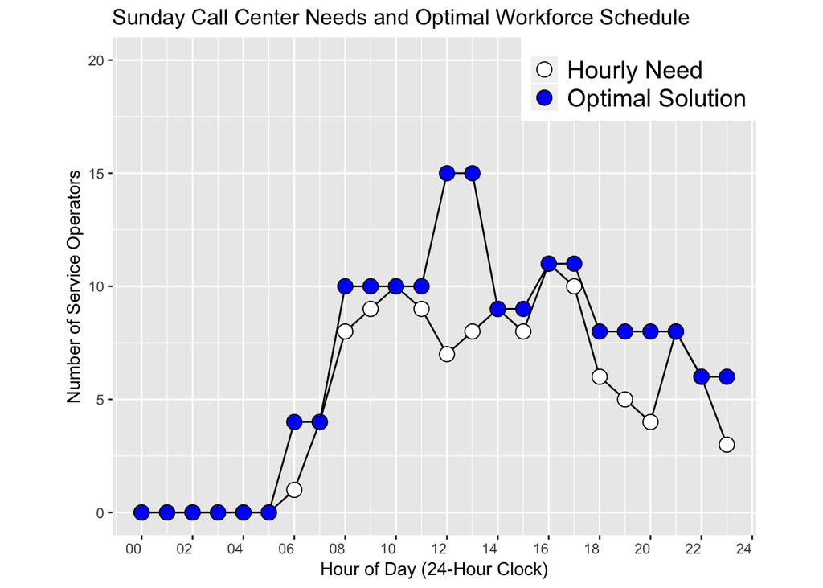